# Making maps with `gfwr`

## Overview

A powerful feature of `gfwr` is the ability to get data for making custom maps of human activity at sea, such as apparent fishing effort, at-sea transshipment, and port visits. The `get_raster()` function provides gridded (e.g. raster) data from GFW’s [4Wings Map Visualization API](https://globalfishingwatch.org/our-apis/documentation#map-visualization-4wings-api) and is useful for making heatmaps, while the `get_events()` function supplies vector data (mostly point locations) from the GFW [Events API](https://globalfishingwatch.org/our-apis/documentation#events-api) for individual vessel events.

> This vignette demonstrates how to use and combine multiple `gfwr` functions to make a variety of maps of fishing vessel activity. Specifically, this vignette will show how to use the `get_raster()` function to make heatmaps of apparent fishing effort, and the `get_events()` function to visualize the locations of specific events. It will demonstrate how to request data for specific regions using `gfwr`’s built-in options, as well as how to use a custom region provided by the user.

### Setup

To get started, first load the `gfwr` package.

```r
library(gfwr)
```

Next, load your API key into your environment with the `gfw_auth()` function (see the [Authorization](https://github.com/GlobalFishingWatch/gfwr?tab=readme-ov-file#authorization) section of the `gfwr` README)

```r
gfw_key <- gfw_auth()
```

For this vignette, we’ll also use some `tidyverse` packages for data wrangling and plotting, as well as `sf` for creating and manipulating spatial data and `rnaturalearth` to add reference data to our maps.

```r
library(tidyverse, quietly = T)
library(sf)
library(rnaturalearth)
library(glue)
```

To make our maps a little nicer, let’s define a custom `ggplot2` theme and a color palette for our heatmaps of apparent fishing effort.

```r
# Map theme with dark background
map_theme <- ggplot2::theme_minimal() +
  ggplot2::theme(
    panel.border = element_blank(),
    legend.position = "bottom", legend.box = "vertical",
    legend.key.height = unit(3, "mm"),
    legend.key.width = unit(20, "mm"),
    legend.text = element_text(color = "#848b9b", size = 8),
    legend.title = element_text(face = "bold", color = "#363c4c", size = 8, hjust = 0.5),
    plot.title = element_text(face = "bold", color = "#363c4c", size = 10),
    plot.subtitle = element_text(color = "#363c4c", size = 10),
    axis.title = element_blank(),
    axis.text = element_text(color = "#848b9b", size = 6)
    )

# Palette for fishing activity
map_effort_light <- c("#ffffff", "#eeff00", "#3b9088","#0c276c")
```

We’ll also define a common date range to use for querying data.

```r
start_date <- '2021-01-01'
end_date <- '2021-03-31'
```

## Making heatmaps of apparent fishing effort with `get_raster()`

The list of available regions for each type, and their `label` and `id`, can be accessed with the `get_regions()` function.

```r
eez_regions <- get_regions(region_source = 'EEZ', key = gfw_key)
```

```r
eez_regions
```

```
#> # A tibble: 282 × 3
#>       id label                                                         iso3
#>    <int> <chr>                                                         <chr>
#>  1  5675 Estonia                                                       EST
#>  2 48944 Mayotte                                                       FRA
#>  3 50170 Overlapping claim Qatar / Saudi Arabia / United Arab Emirates QAT
#>  4  8475 Cameroon                                                      CMR
#>  5  5676 Finland                                                       FIN
#>  6  8340 Bassas da India                                               FRA
#>  7  8435 Faeroe                                                        DNK
#>  8  8488 Gilbert Islands                                               KIR
#>  9 48971 Overlapping claim: Venezuela / Colombia / Dominican Republic  COL
#> 10  8474 Nigeria                                                       NGA
#> # ℹ 272 more rows
```

`gfwr` also includes the `get_region_id()` function to get the `label` and `id` for a specific region using the `region_name` argument. For EEZs, the `region_name` corresponds to the ISO3 code. Note that, for some countries, the ISO3 code will return multiple regions. For RFMOs, `region_name` corresponds to the RFMO abbreviation (e.g. `"ICCAT"`) and for MPAs it refers to the full name of the MPA. The `get_region_id()` function also works in reverse. If a region `id` is passed as a `numeric` to the function as the `region_name`, the corresponding region `label` can be returned. This is especially useful when events are returned with region ids and you want the more descriptive label. See [here](https://globalfishingwatch.org/faqs/reference-layer-sources/) for more information about the regions used by GFW.

Let’s start by making a map of apparent fishing effort in the Italian EEZ. The `get_raster()` function requires we provide the `id` of a specific region (or a GeoJSON, but more on that later). We could look up the Italian EEZ `id` in the `eez_regions` table we just created, but let’s use `get_region_id()`.

```r
# Use get_region_id function to get EEZ code for Italy
ita_eez_code <- get_region_id(region_name = "ITA", region_source = "EEZ", key = gfw_auth())
```

```
#> # A tibble: 1 × 3
#>      id label iso3
#>   <dbl> <chr> <chr>
#> 1  5682 Italy ITA
```

The `get_raster()` function allows users to specify multiple criteria to customize the data they download, including the date range, spatial and temporal resolution, and grouping variables. See the documentation for `get_raster()` or the [GFW APIs](https://globalfishingwatch.org/our-apis/documentation#report-url-parameters-for-both-post-and-get-requests) for more info about these parameter options.

In this case, let’s request data during our time range at 100th degree resolution and grouped by flag State:

```r
# Download data for the Italian EEZ
eez_fish_df <- get_raster(
  spatial_resolution = "HIGH",
  temporal_resolution = "YEARLY",
  group_by = "FLAG",
  date_range = paste0(start_date,',',end_date),
  region = ita_eez_code$id,
  region_source = "EEZ"
  )
```

```
#> # A tibble: 69,142 × 6
#>      Lat   Lon `Time Range` flag  `Vessel IDs` `Apparent Fishing Hours`
#>    <dbl> <dbl>        <dbl> <chr>        <dbl>                    <dbl>
#>  1  44.2  9.19         2021 ITA             12                     54.0
#>  2  37.5 12.9          2021 ITA             13                     19.5
#>  3  37.5 13.0          2021 ITA             12                     32.6
#>  4  37.4 13.2          2021 ITA             13                     22.6
#>  5  37.4 13.1          2021 ITA             13                     15.9
#>  6  37.4 13.1          2021 ITA             19                     24.4
#>  7  37.4 13.2          2021 ITA             16                     15.7
#>  8  37.4 13.2          2021 ITA             16                     21.3
#>  9  37.4 13.2          2021 ITA             14                     30.2
#> 10  37.3 13.4          2021 ITA             13                     10.5
#> # ℹ 69,132 more rows
```

Because the data includes fishing by all flag states, to make a map of all activity, we first need to summarize activity by grid cell.

```r
eez_fish_all_df <- eez_fish_df %>%
  group_by(Lat, Lon) %>%
  summarize(fishing_hours = sum(`Apparent Fishing Hours`, na.rm = T))
```

[output not shown]

Now we can use `ggplot2` to plot the data:

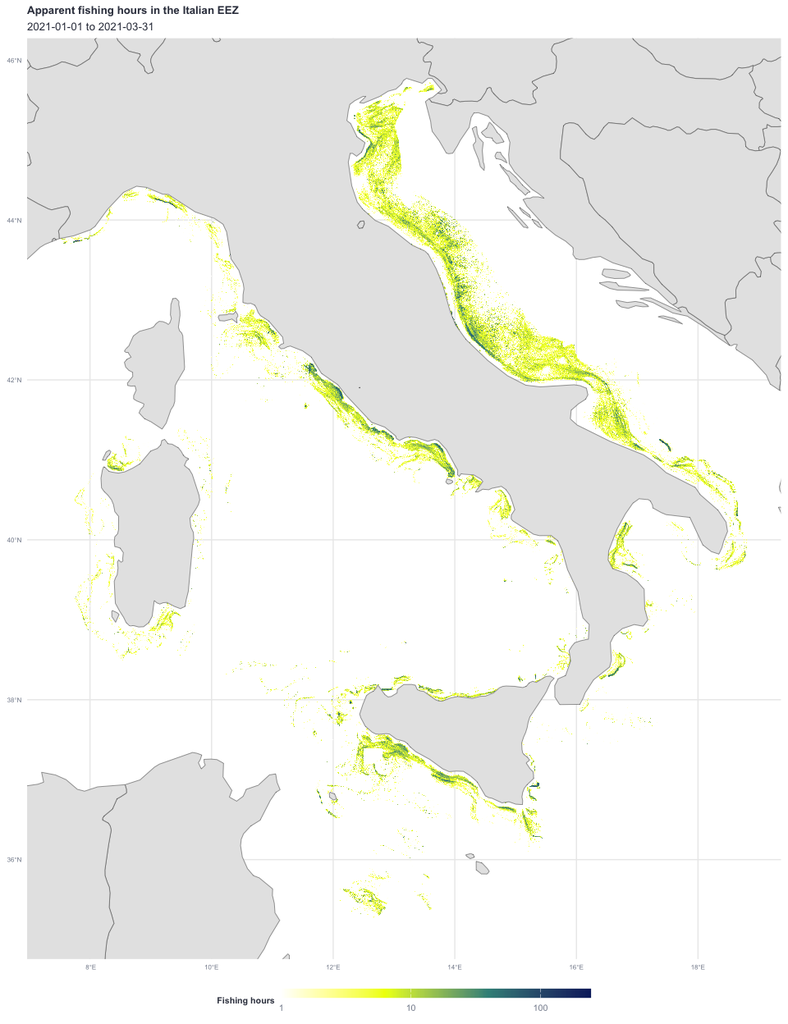

```r
eez_fish_all_df %>%
  filter(fishing_hours >= 1) %>%
  ggplot() +
  geom_raster(aes(x = Lon,
                  y = Lat,
                  fill = fishing_hours)) +
  geom_sf(data = ne_countries(returnclass = "sf", scale = "medium")) +
  coord_sf(xlim = c(min(eez_fish_all_df$Lon),max(eez_fish_all_df$Lon)),
           ylim = c(min(eez_fish_all_df$Lat),max(eez_fish_all_df$Lat))) +
  scale_fill_gradientn(
    trans = 'log10',
    colors = map_effort_light,
    na.value = NA,
    labels = scales::comma) +
  labs(title = "Apparent fishing hours in the Italian EEZ",
       subtitle = glue("{start_date} to {end_date}"),
       fill = "Fishing hours") +
  map_theme
```

As another example, let’s request low resolution apparent fishing effort data within the jurisdiction of the Indian Ocean Tuna Commission (IOTC), grouped yearly by gear type:

```r
# Download data for the IOTC
iotc_fish_df <- get_raster(
  spatial_resolution = "LOW",
  temporal_resolution = "YEARLY",
  group_by = "GEARTYPE",
  date_range = paste0(start_date,',',end_date),
  region = "IOTC",
  region_source = "RFMO"
  )
```

```
#> # A tibble: 106,229 × 6
#>      Lat   Lon `Time Range` geartype      `Vessel IDs` `Apparent Fishing Hours`
#>    <dbl> <dbl>        <dbl> <chr>                <dbl>                    <dbl>
#>  1  26.5  50.2         2021 trawlers                10                     82.2
#>  2  26.2  50.6         2021 set_longlines           13                    128.
#>  3  26.2  50.6         2021 fishing                 13                     41.4
#>  4  26.9  50.8         2021 fishing                  9                     92.0
#>  5  26.9  51           2021 fishing                 14                    498.
#>  6  26.9  50.9         2021 set_longlines           10                    123.
#>  7  26.9  51           2021 set_longlines           17                    386.
#>  8  26.8  50.8         2021 fishing                 11                    144.
#>  9  26.8  50.9         2021 fishing                 12                    165.
#> 10  26.9  50.9         2021 fishing                 10                    117.
#> # ℹ 106,219 more rows
```

This time, instead of aggregating all activity, let’s plot the activity of a specific gear type:

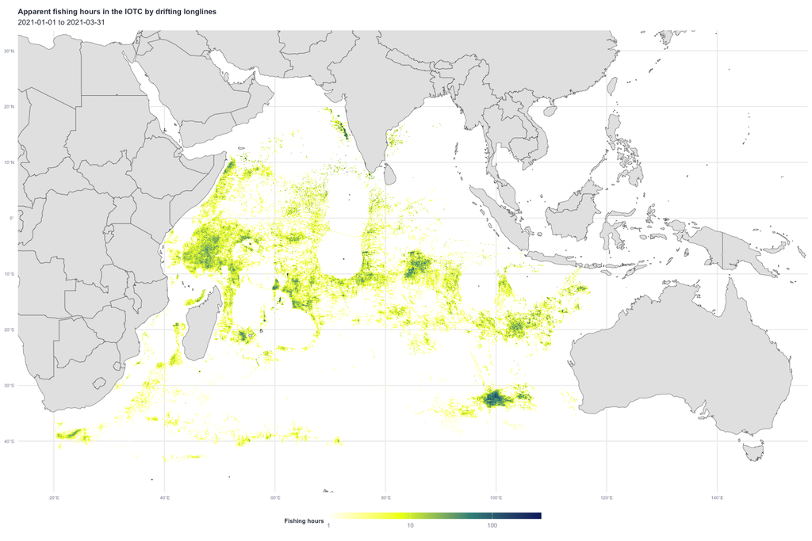

```r
iotc_p1 <- iotc_fish_df %>%
  filter(geartype == 'drifting_longlines') %>%
  filter(`Apparent Fishing Hours` >= 1) %>%
  ggplot() +
  geom_raster(aes(x = Lon,
                  y = Lat,
                  fill = `Apparent Fishing Hours`)) +
  geom_sf(data = ne_countries(returnclass = "sf", scale = "medium")) +
  coord_sf(xlim = c(min(iotc_fish_df$Lon),max(iotc_fish_df$Lon)),
           ylim = c(min(iotc_fish_df$Lat),max(iotc_fish_df$Lat))) +
  scale_fill_gradientn(
    transform = 'log10',
    breaks = c(1,10,100),
    colors = map_effort_light,
    na.value = NA,
    labels = scales::comma) +
  labs(title = "Apparent fishing hours in the IOTC by drifting longlines",
       subtitle = glue("{start_date} to {end_date}"),
       fill = "Fishing hours") +
  map_theme

iotc_p1
```

### When your API request times out

For API performance reasons, the `get_raster()` function restricts individual queries to a single year of data. However, even with this restriction, it is possible for API request to time out before it completes. When this occurs, the initial `get_raster()` call will return an error, and subsequent API requests using any `gfwr` `get_` function will return an HTTP 429 error until the original request completes:

> Error in `httr2::req_perform()`: ! HTTP 429 Too Many Requests. • Your application token is not currently enabled to perform more than one concurrent report. If you need to generate more than one report concurrently, contact us at apis@globalfishingwatch.org

Although no data was received, the request is still being processed by the APIs and will become available when it completes. To account for this, `gfwr` includes the `get_last_report()` function, which let’s users request the results of their last API request with `get_raster()`.

The `get_last_report()` function will tell you if the APIs are still processing your request and will download the results if the request has finished successfully. You will receive an error message if the request finished but resulted in an error or if it’s been >30 minutes since the last report was generated using `get_raster()`. For more information, see the [Get last report generated endpoint](https://globalfishingwatch.org/our-apis/documentation#get-last-report-generated) documentation on the GFW API page.

If you’re struggling with this issue, we suggest breaking your request into smaller individual requests and then binding the results in R.

## Plotting vessel events

The `get_event()` function provides spatial data about the location of specific vessel activities. There are currently five available event types (`"FISHING"`,`"ENCOUNTER"`,`"LOITERING"`, `"PORT VISIT"`, and `"GAP"`) and the `vessel-types` argument allow users to request events for different categories of vessels (e.g. `"FISHING"`, `"CARRIER"`, `"CARGO"`, etc.). There are also a few event-specific arguments for specifying things like encounter types and confidence levels. For more details, see the `get_event()` function documentation and the [GFW API documentation](https://globalfishingwatch.org/our-apis/documentation#data-caveat).

In this example, we will use `get_event()` to request encounter events between fishing vessels and refrigerated carrier vessels. We’ll restrict events to those within the jurisdiction of the Indian Ocean Tuna Commission (IOTC) using the `region` and `region_source` arguments like we did in the previous example.

```r
# using same example as above
encounters_df <- get_event(event_type = "ENCOUNTER",
                           encounter_types = "CARRIER-FISHING",
                           start_date = start_date,
                           end_date = end_date,
                           region = "IOTC",
                           region_source = "RFMO")
```

```
#> [1] "Downloading 176 events from GFW"
```

Encounters events have two rows per event to represent both vessels. Because each row shares the same event ID (`event_id`), we can extract the `event_id` and select one row per `event_id` to remove duplicate positions. We’ll also use the `lon` and `lat` coordinates to create a `sf` object for each encounter event.

```r
encounters_sf_df <- encounters_df %>%
  tidyr::separate(id, c("event_id","vessel_number")) %>%
  filter(vessel_number == 1) %>%
  sf::st_as_sf(coords = c("lon","lat"), crs = 4326) %>%
  select(event_id, type, geometry)
```

To assist with plotting, let’s get the bounding box of the encounter events.

```r
enc_bbox <- st_bbox(encounters_sf_df)
```

Now let’s add the encounters layer to our previous map of drifting longline effort in the IOTC and use the bounding box to restrict the plot to the area with encounters.

[output not shown]

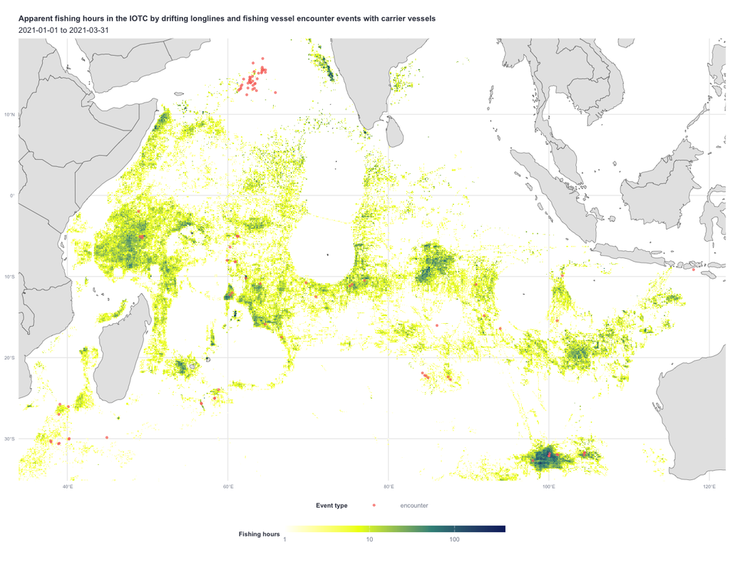

```r
iotc_p1 +
  geom_sf(data = encounters_sf_df,
          aes(color = type),
          alpha = 0.7, size = 1) +
  coord_sf(xlim = enc_bbox[c(1,3)],
           ylim = enc_bbox[c(2,4)]) +
  labs(title = 'Apparent fishing hours in the IOTC by drifting longlines and fishing vessel encounter events with carrier vessels',
       color = 'Event type')
```

## Making maps for custom regions

The `get_raster()` and `get_event()` functions also allow users to download data within a custom region by providing a GeoJSON polygon. To facilitate this, the `get_raster()` and `get_event()` functions allow users to pass a `sf` object to the `region` argument.

To demonstrate this, we’ll first create a tibble of coordinates defining an arbitrary polygon and convert to an `sf` object.

```r
my_shp <- tibble(
  lon = c(-96,-96,-66,-66,-96),
  lat = c(-24,4,4,-24,-24)
  ) %>%
  sf::st_as_sf(
    coords = c('lon','lat'),
    crs = "+init=epsg:4326 +proj=longlat +ellps=WGS84 +datum=WGS84 +no_defs +towgs84=0,0,0"
    ) %>%
  summarize(geometry = st_combine(geometry)) %>%
  st_cast("POLYGON")
```

Plot the `sf` object to confirm it was created successfully.

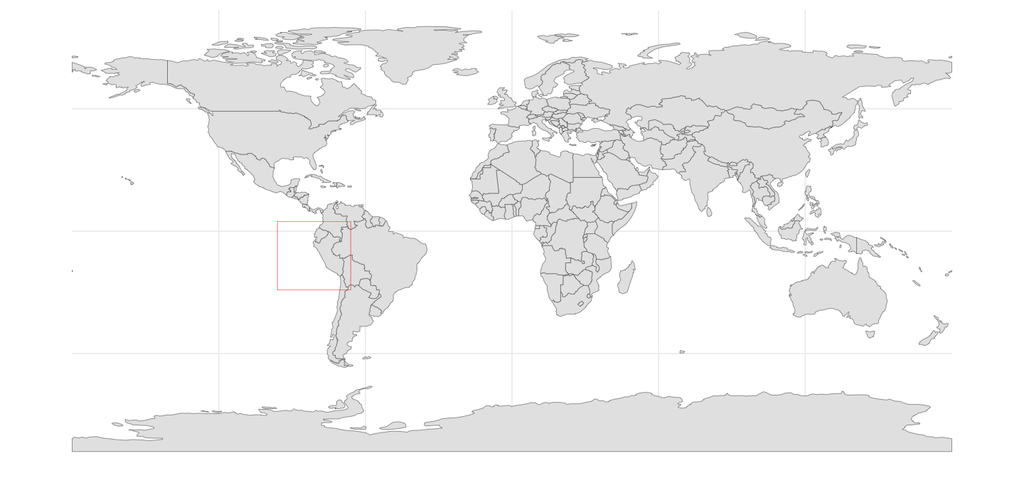

```r
ggplot() +
  geom_sf(data = ne_countries(returnclass = "sf", scale = "small")) +
  geom_sf(
    data = my_shp,
    fill = NA,
    color = 'red') +
  map_theme
```

Let’s create a `sf` bounding box object for our region to use for plotting later. Although our shape is a simple rectangle in this example, this is helpful when using more complex regions.

```r
my_shp_bbox <- st_bbox(my_shp)
```

Now we’re ready to request data in our custom region from `get_raster()` and `get_events()`.

```r
my_raster_df <- get_raster(
  spatial_resolution = "LOW",
  temporal_resolution = "YEARLY",
  group_by = "GEARTYPE",
  date_range = paste0(start_date,',',end_date),
  region = my_shp,
  region_source = "USER_JSON"
  )
```

For events, we’ll request high-confidence port visits by fishing vessels

```r
my_port_events_df <- get_event(event_type = "PORT_VISIT",
                          confidences = 4,
                          vessel_types = "FISHING",
                          start_date = start_date,
                          end_date = end_date,
                          region = my_shp,
                          region_source = "USER_JSON")
```

```
#> [1] "Downloading 3983 events from GFW"
```

and loitering events by refrigerated cargo vessels

```r
my_loitering_events_df <- get_event(event_type = "LOITERING",
                                    vessel_types = "CARRIER",
                                    start_date = start_date,
                                    end_date = end_date,
                                    region = my_shp,
                                    region_source = "USER_JSON")
```

```
#> [1] "Downloading 50 events from GFW"
```

As before, let’s summarize the raster to plot all fishing activity by fishing vessels

```r
my_raster_all_df <- my_raster_df %>%
  group_by(Lat, Lon) %>%
  summarize(fishing_hours = sum(`Apparent Fishing Hours`, na.rm = T))
```

[output not shown]

and combine our two event datasets and create `sf` objects for each event.

```r
my_events_sf <- my_port_events_df %>%
  select(id, lon, lat, type) %>%
  bind_rows(
    my_loitering_events_df %>%
      select(id, lon, lat, type)
  ) %>%
  sf::st_as_sf(coords = c("lon","lat"), crs = 4326) %>%
  select(id, type, geometry)
```

Finally, let’s plot the fishing effort raster and overlay the loitering events and port visits.

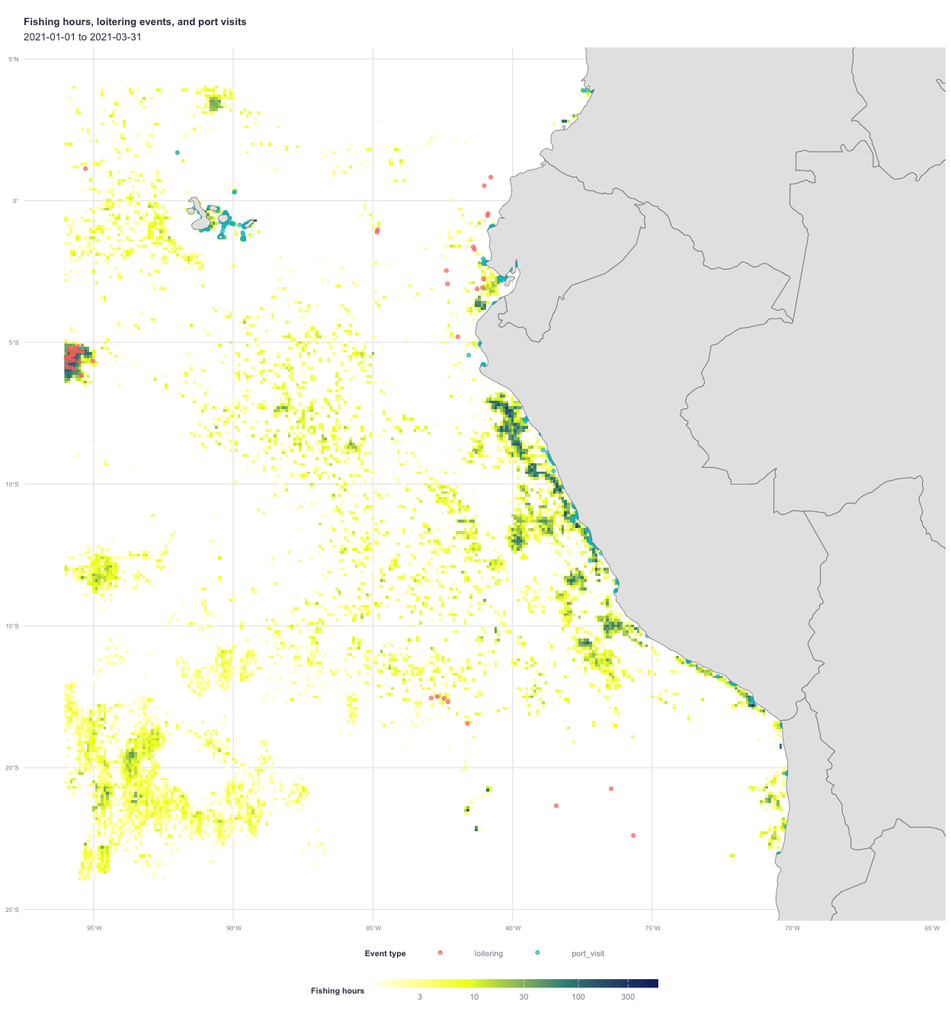

```r
my_raster_all_df %>%
  filter(fishing_hours > 1) %>%
  ggplot() +
  geom_raster(aes(x = Lon,
                  y = Lat,
                  fill = fishing_hours)) +
  geom_sf(data = my_events_sf,
          aes(color = type),
          alpha = 0.7) +
  geom_sf(data = ne_countries(returnclass = 'sf', scale = 'medium')) +
  coord_sf(xlim = my_shp_bbox[c(1,3)],
           ylim = my_shp_bbox[c(2,4)]) +
  scale_fill_gradientn(
    transform = 'log10',
    colors = map_effort_light,
    na.value = NA) +
  labs(
    title = 'Fishing hours, loitering events, and port visits',
    subtitle = glue("{start_date} to {end_date}"),
    fill = 'Fishing hours',
    color = 'Event type'
  ) +
  map_theme
```